# Tutorial_01

## Tutorial 01 - Using upROOT

## Basic upROOT usage

First, we need to `import` the `upROOT` package:

```python
import uproot
```

**Important!**  
Make sure that you have upROOT version 3.4.15 - they recently added the support needed to read all data types that are used in our PicoDst format

```python
uproot.__version__
```

```
'3.4.15'
```

If you dont have the most updated version use:

```
pip install uproot --update
```

or

```
conda update uproot
```

depending on whether you installed it with `pip` or `conda`

upROOT makes it very easy to read data from ROOT data files. We can open a single file easily using the `open` method:

```python
f = uproot.open( "/Users/jdb/bnl/work/MLatSTAR/st_physics_20057002_raw_7500003.picoDst.root" )
f.keys()
```

```
[b'PicoDst;1']
```

upROOT documentation describes all of the methods that we use and their additional options: https://github.com/scikit-hep/uproot

After opening the file we can see whats in it by using the `keys` method. In this PicoDst file, we have only one key, the `PicoDst` TTree. We can get the `PicoDst` out and begin looking at the data:

```python
PicoDst = f["PicoDst"]
PicoDst.show()
```

```
Event                      TStreamerInfo              asdtype('>i4')
Event.mRunId               TStreamerBasicType         asjagged(asdtype('>i4'))
Event.mEventId             TStreamerBasicType         asjagged(asdtype('>i4'))
Event.mFillId              TStreamerBasicType         asjagged(asdtype('>u2'))
Event.mBField              TStreamerBasicType         asjagged(asdtype('>f4'))
Event.mTime                TStreamerBasicType         asjagged(asdtype('>i4'))
Event.mPrimaryVertexX      TStreamerBasicType         asjagged(asdtype('>f4'))
Event.mPrimaryVertexY      TStreamerBasicType         asjagged(asdtype('>f4'))
Event.mPrimaryVertexZ      TStreamerBasicType         asjagged(asdtype('>f4'))
Event.mPrimaryVertexErrorX TStreamerBasicType         asjagged(asdtype('>f4'))
Event.mPrimaryVertexErrorY TStreamerBasicType         asjagged(asdtype('>f4'))
Event.mPrimaryVertexErrorZ TStreamerBasicType         asjagged(asdtype('>f4'))
Event.mRanking             TStreamerBasicType         asjagged(asdtype('>f4'))
Event.mNBEMCMatch          TStreamerBasicType         asjagged(asdtype('>u2'))
Event.mNBTOFMatch          TStreamerBasicType         asjagged(asdtype('>u2'))
Event.mTriggerIds          TStreamerSTL               asgenobj(SimpleArray(STLVector(asdtype('>i2'))))
Event.mRefMultFtpcEast     TStreamerBasicType         asjagged(asdtype('>u2'))
Event.mRefMultFtpcWest     TStreamerBasicType         asjagged(asdtype('>u2'))
Event.mRefMultNeg          TStreamerBasicType         asjagged(asdtype('>u2'))
Event.mRefMultPos          TStreamerBasicType         asjagged(asdtype('>u2'))
Event.mRefMult2NegEast     TStreamerBasicType         asjagged(asdtype('>u2'))
Event.mRefMult2PosEast     TStreamerBasicType         asjagged(asdtype('>u2'))
Event.mRefMult2NegWest     TStreamerBasicType         asjagged(asdtype('>u2'))
Event.mRefMult2PosWest     TStreamerBasicType         asjagged(asdtype('>u2'))
Event.mRefMult3NegEast     TStreamerBasicType         asjagged(asdtype('>u2'))
Event.mRefMult3PosEast     TStreamerBasicType         asjagged(asdtype('>u2'))
Event.mRefMult3NegWest     TStreamerBasicType         asjagged(asdtype('>u2'))
Event.mRefMult3PosWest     TStreamerBasicType         asjagged(asdtype('>u2'))
Event.mRefMult4NegEast     TStreamerBasicType         asjagged(asdtype('>u2'))
Event.mRefMult4PosEast     TStreamerBasicType         asjagged(asdtype('>u2'))
Event.mRefMult4NegWest     TStreamerBasicType         asjagged(asdtype('>u2'))
Event.mRefMult4PosWest     TStreamerBasicType         asjagged(asdtype('>u2'))
Event.mRefMultHalfNegEast  TStreamerBasicType         asjagged(asdtype('>u2'))
Event.mRefMultHalfPosEast  TStreamerBasicType         asjagged(asdtype('>u2'))
Event.mRefMultHalfNegWest  TStreamerBasicType         asjagged(asdtype('>u2'))
Event.mRefMultHalfPosWest  TStreamerBasicType         asjagged(asdtype('>u2'))
Event.mGRefMult            TStreamerBasicType         asjagged(asdtype('>u2'))
Event.mNumberOfGlobalTracks
                           TStreamerBasicType         asjagged(asdtype('>u2'))
Event.mbTofTrayMultiplicity
```

[output cut: 145 more lines]

```
MtdPidTraits.mDeltaZ       TStreamerBasicType         asjagged(asdtype('>i2'))
MtdPidTraits.mDeltaTimeOfFlight
                           TStreamerBasicType         asjagged(asdtype('>f4'))
MtdPidTraits.mBeta         TStreamerBasicType         asjagged(asdtype('>u2'))
MtdPidTraits.mMtdHitChan   TStreamerBasicType         asjagged(asdtype('>i2'))

TrackCovMatrix             TStreamerInfo              asdtype('>i4')
TrackCovMatrix.mImp        TStreamerBasicType         asjagged(asfloat16(0, 0, 12, dtype([('exponent', 'u1'), ('mantissa', '>u2')]), dtype('float32')))
TrackCovMatrix.mZ          TStreamerBasicType         asjagged(asfloat16(0, 0, 12, dtype([('exponent', 'u1'), ('mantissa', '>u2')]), dtype('float32')))
TrackCovMatrix.mPsi        TStreamerBasicType         asjagged(asfloat16(-3.141592653589793, 3.141592653589793, 20, dtype('>u4'), dtype('float32')))
TrackCovMatrix.mPti        TStreamerBasicType         asjagged(asfloat16(0, 0, 12, dtype([('exponent', 'u1'), ('mantissa', '>u2')]), dtype('float32')))
TrackCovMatrix.mTan        TStreamerBasicType         asjagged(asfloat16(-10.0, 10.0, 20, dtype('>u4'), dtype('float32')))
TrackCovMatrix.mCurv       TStreamerBasicType         asjagged(asfloat16(0, 0, 12, dtype([('exponent', 'u1'), ('mantissa', '>u2')]), dtype('float32')))
TrackCovMatrix.mSigma[5]   TStreamerBasicType         asjagged(asfloat16(0, 0, 12, dtype(([('exponent', 'u1'), ('mantissa', '>u2')], (5,))), dtype(('<f4', (5,)))))
TrackCovMatrix.mCorr[10]   TStreamerBasicType         asjagged(asfloat16(-1.0, 1.0, 20, dtype(('>u4', (10,))), dtype(('<f4', (10,)))))
```

The `show` member shows us what the PicoDst format includes. The 2nd and 3rd columns include information about how the informantion is read out of the ROOT TTree. Most of the time the default works perfectly, but if needed you can override how the data is read to support complex/custom data types.

We can also use `PicoDst.allkeys()` if we just want the name of the keys

## Making simple plots with MatPlotLib

Here are some examples demonstrating how to read several files (like a TChain) and make plots. These plots are generated with `matplotlib` (https://matplotlib.org/) - a framework for making publication quality plots and visualizations in python.

First we need to import matplotlib:

```python
import matplotlib.pyplot as plt
fs = ( 32, 18 ) # lets make all our figures 16 by 9
```

```python
vz = np.array([])
for arrays in uproot.iterate( "/Users/jdb/bnl/work/MLatSTAR/*.picoDst.root", "PicoDst", ["Event.mPrimaryVertexZ"] ) :
    print("CHUNK")
    # The array of vz values from this chunk
    cvz = arrays[b"Event.mPrimaryVertexZ"].flatten()
    if vz.shape == (0,) : #first asignment
        vz = cvz
    else :
        # add the chunk to the existing array
        vz = numpy.concatenate( (vz, cvz) )
```

```
CHUNK
CHUNK
CHUNK
CHUNK
CHUNK
CHUNK
CHUNK
CHUNK
CHUNK
CHUNK
CHUNK
CHUNK
CHUNK
```

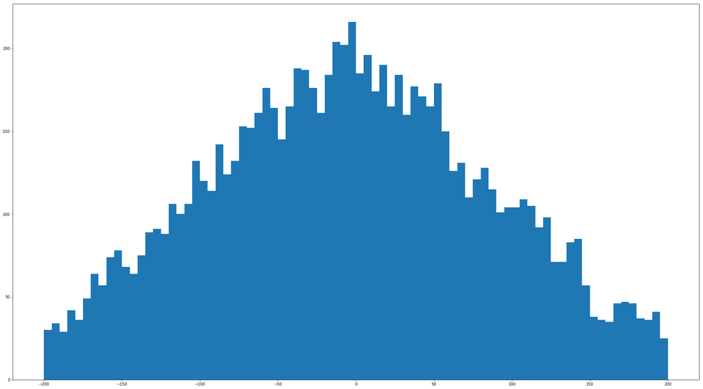

```python
plt.figure(figsize=fs)
plt.hist( vz, bins=range(-200, 205, 5) );
```

```python
tracksXYZ = PicoDst.arrays( ["Track.mOriginX", "Track.mOriginY", "Track.mOriginZ"] )
```

```python
tracksXYZ
```

```
{b'Track.mOriginX': <JaggedArray [[-27.451181411743164 23.289833068847656 -68.8012924194336 ... 53.565032958984375 -14.044007301330566 46.578125] [10.52143383026123 -15.51406478881836 -0.25029289722442627 ... 7.928201198577881 2.493062734603882 50.67344284057617] [15.501043319702148 6.40270662307739…
 b'Track.mOriginY': <JaggedArray [[-62.80702590942383 -3.9521381855010986 11.854799270629883 ... 51.0650634765625 -27.548555374145508 -2.1429951190948486] [0.3646497428417206 3.320474147796631 0.06802668422460556 ... -12.37744140625 -2.3237686157226562 -18.679424285888672] [66.76382446289062 -69.991…
 b'Track.mOriginZ': <JaggedArray [[-21.307950973510742 57.92173767089844 -26.634912490844727 ... -41.69431686401367 -133.16598510742188 -60.16699981689453] [56.593055725097656 51.994834899902344 67.8997573852539 ... 81.7162857055664 68.22417449951172 79.24315643310547] [64.352783203125 75.1898956298…
```

We can see that the result is an array (object) where the 1st index is the variable name, second index is the event number, and the 3rd index is the track.

So:

```
tracksXYZ["Track.mOriginX"][100][12]
```

is the Track's X origin in event 100 for track number 12

Lets look at the tracks in the first event:

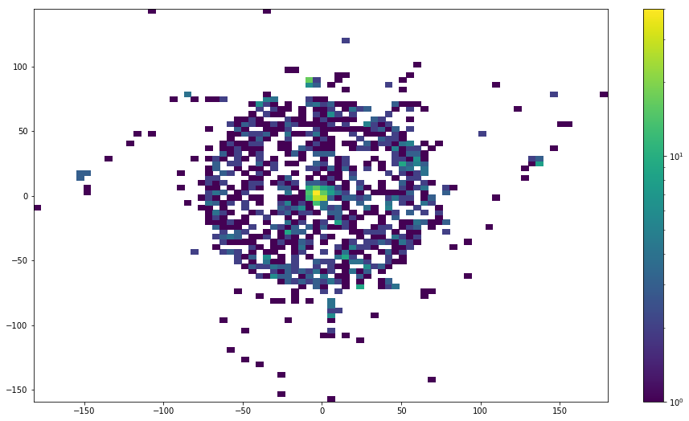

```python
from matplotlib.colors import LogNorm
plt.figure(figsize=fs)
plt.hist2d( tracksXYZ[b"Track.mOriginX"][0], tracksXYZ[b"Track.mOriginY"][0], bins=(80, 80), norm=LogNorm())
plt.colorbar()
plt.show()
```

Now lets `flatten` the arrays to look at all events

```python
allX = tracksXYZ[b"Track.mOriginX"].flatten()
allY = tracksXYZ[b"Track.mOriginY"].flatten()
allZ = tracksXYZ[b"Track.mOriginZ"].flatten()
```

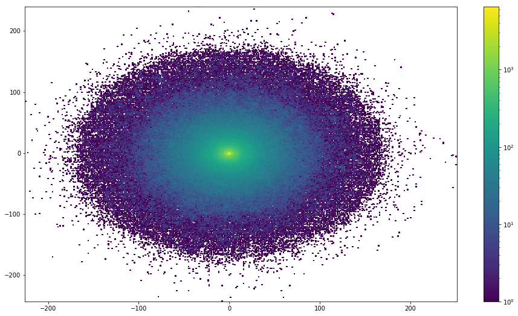

```python
plt.figure(figsize=fs)
plt.hist2d( allX, allY, bins=400, norm=LogNorm())
plt.colorbar()
plt.show()
```

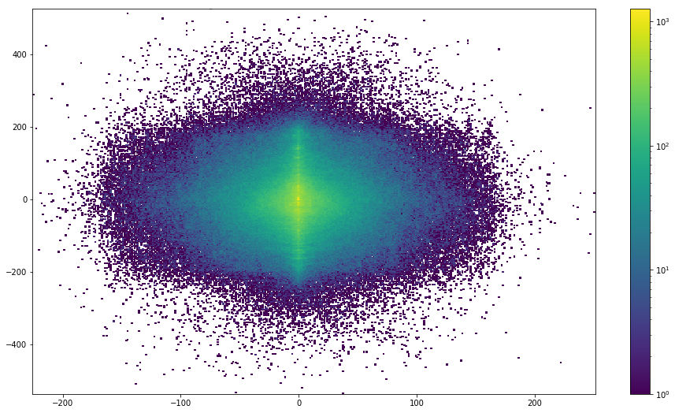

```python
plt.figure(figsize=fs)
plt.hist2d( allX, allZ, bins=400, norm=LogNorm())
plt.colorbar()
plt.show()
```

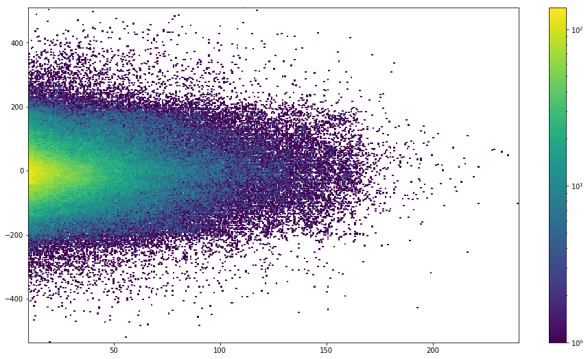

```python
plt.figure(figsize=fs)
plt.hist2d( [y for y in allY if y > 10], [z for y,z in zip(allY, allZ) if y > 10], bins=400, norm=LogNorm())
plt.colorbar()
plt.show()
```

## Reading from multiple PicoDst.root files

Next, lets read data from all of the `PicoDsts` in a directory and plot the Z vertex:

We also need numpy for working with arrays efficiently in python, so lets import it:

```python
import numpy
```

```python
vz = np.array([])
for arrays in uproot.iterate( "/Users/jdb/bnl/work/MLatSTAR/*", "PicoDst", ["Event.mPrimaryVertexZ"], entrysteps=10000000 ) :
    print("CHUNK")
    if vz.shape == (0,) : #first asignment
        vz = arrays[b"Event.mPrimaryVertexZ"].flatten()
    else :
        na = arrays[b"Event.mPrimaryVertexZ"].flatten()
        vz = numpy.concatenate( (vz, na) )
```

```
CHUNK
CHUNK
CHUNK
CHUNK
CHUNK
CHUNK
CHUNK
CHUNK
CHUNK
CHUNK
CHUNK
CHUNK
```

Lets make sure we got all of the events:

```python
len(vz) #should be 9012 for these files
```

```
9012
```

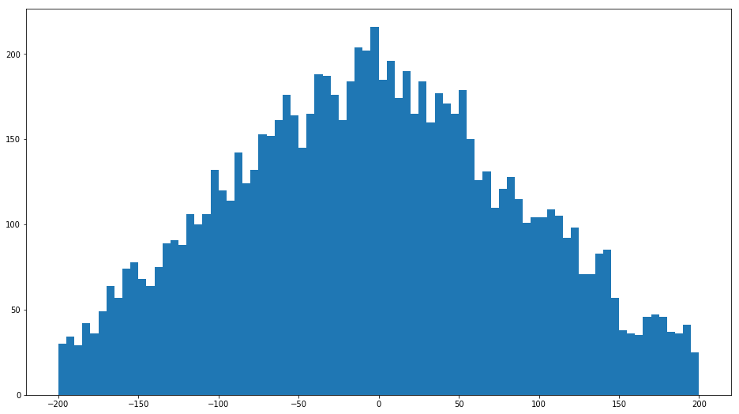

```python
plt.figure(figsize=fs)
plt.hist( vz, bins=range(-200, 205, 5) );
```

Now lets look at the Radial vertex distribution:

```python
vr = np.array([])
for arrays in uproot.iterate( "/Users/jdb/bnl/work/MLatSTAR/*.picoDst.root", "PicoDst", ["Event.mPrimaryVertexX", "Event.mPrimaryVertexY"] ) :
    print("CHUNK")
    x = arrays[b"Event.mPrimaryVertexX"].flatten()
    y = arrays[b"Event.mPrimaryVertexY"].flatten()
    if vr.shape == (0,) : #first asignment
        vr = numpy.sqrt( x*x + y*y )
    else :
        vr = numpy.concatenate( (vr, numpy.sqrt( x*x + y*y ) ) )
```

```
CHUNK
CHUNK
CHUNK
CHUNK
CHUNK
CHUNK
CHUNK
CHUNK
CHUNK
CHUNK
CHUNK
CHUNK
CHUNK
```

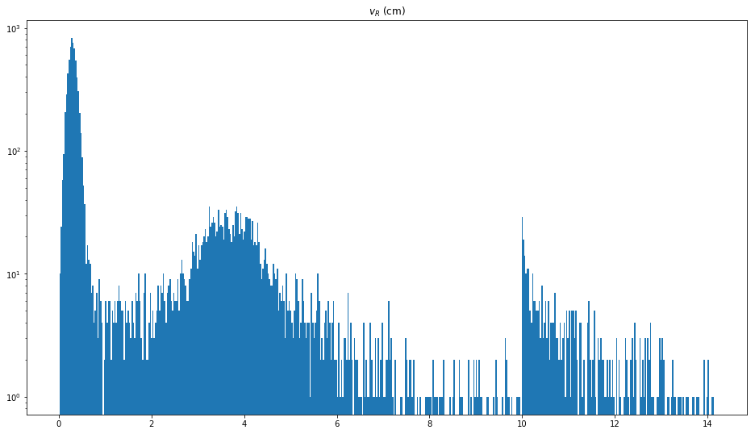

```python
plt.figure(figsize=fs)
plt.hist(vr, bins=500)
plt.yscale('log')
plt.title( r'$v_R$ (cm)' )
plt.show()
```

```python
vz = np.array([])
for arrays in uproot.iterate( "/Users/jdb/bnl/work/MLatSTAR/*.picoDst.root", "PicoDst", ["Event.mPrimaryVertexX", "Event.mPrimaryVertexY", "Event.mPrimaryVertexZ"], entrysteps=10000000 ) :
    print("CHUNK")
    chunk_vz = numpy.array(
        [ z for x, y, z in
             zip( arrays[b"Event.mPrimaryVertexX"].flatten(),
                arrays[b"Event.mPrimaryVertexY"].flatten(),
                 arrays[b"Event.mPrimaryVertexZ"].flatten() ) #end of zip
         if numpy.sqrt(x*x + y*y) < 2.5 ])
    if vz.shape == (0,) : #first asignment
        vz = chunk_vz
    else :
        vz = numpy.concatenate( (vz, chunk_vz) )
```

```
CHUNK
CHUNK
CHUNK
CHUNK
CHUNK
CHUNK
CHUNK
CHUNK
CHUNK
CHUNK
CHUNK
CHUNK
```

How many events survived the cuts?

```python
len(vz) #should be 9012 for these files
```

```
6778
```

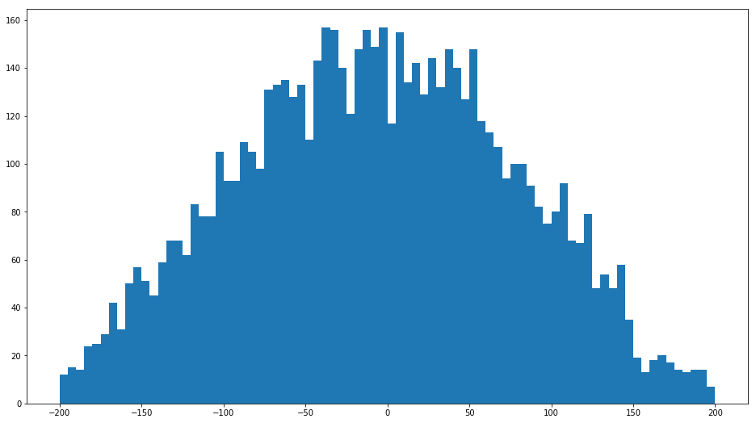

```python
plt.figure(figsize=fs)
plt.hist( vz, bins=range(-200, 205, 5) );
```

```python
PicoDst.pandas.df( ["Event.mPrimaryVertexX", "Event.mPrimaryVertexY", "Event.mPrimaryVertexZ"] )
```

| entry | subentry | Event.mPrimaryVertexX | Event.mPrimaryVertexY | Event.mPrimaryVertexZ |
| --- | --- | --- | --- | --- |
| 0 | 0 | 0.017505 | -0.249257 | 31.691710 |
| 1 | 0 | -0.199586 | -0.278899 | 135.509094 |
| 2 | 0 | 2.384591 | 0.105205 | 56.565784 |
| 3 | 0 | -1.835639 | -1.435089 | -168.726410 |
| 4 | 0 | 0.076531 | -0.335175 | 25.244837 |
| 5 | 0 | -0.029504 | -0.187406 | 94.109978 |
| 6 | 0 | 2.016147 | -2.981740 | -110.357941 |
| 7 | 0 | 0.188017 | -0.617339 | 22.421621 |
| 8 | 0 | 0.012191 | -0.243676 | 60.166950 |
| 9 | 0 | 0.098041 | -0.267664 | -16.320362 |
| 10 | 0 | 0.061299 | -0.232299 | 6.714558 |
| 11 | 0 | 0.219717 | -0.332479 | -102.187294 |
| 12 | 0 | 0.189745 | -0.273927 | 14.115551 |
| 13 | 0 | 0.203753 | -0.359147 | -171.791870 |
| 14 | 0 | 3.396756 | 0.040811 | 188.496643 |
| 15 | 0 | 0.096572 | -0.457225 | -77.258415 |
| 16 | 0 | 0.308939 | -0.340947 | -71.318680 |
| 17 | 0 | 0.149003 | -0.121757 | -96.795120 |
| 18 | 0 | 0.066827 | -0.124075 | -91.325706 |
| 19 | 0 | 0.013484 | -0.173874 | 51.881020 |
| 20 | 0 | 0.060967 | -0.240293 | -11.165607 |
| 21 | 0 | 0.654979 | 3.021051 | 156.600601 |
| 22 | 0 | 0.225604 | -0.178776 | -162.321259 |
| 23 | 0 | -0.083508 | -0.305524 | 31.510031 |
| 24 | 0 | 0.126910 | -0.228782 | 16.616884 |
| 25 | 0 | 0.062028 | -0.263780 | 80.548363 |
| 26 | 0 | 0.204261 | 3.919365 | -71.016479 |
| 27 | 0 | 0.242324 | -0.318244 | -104.017181 |
| 28 | 0 | 0.855872 | -2.843530 | -60.124069 |
| 29 | 0 | 1.416582 | -4.404632 | 86.484116 |
| ... | ... | ... | ... | ... |
| 910 | 0 | 0.054059 | 0.031702 | -30.112377 |
| 911 | 0 | 0.181068 | -3.916540 | -172.617264 |
| 912 | 0 | 0.003093 | -0.365384 | 22.886946 |
| 913 | 0 | 0.891896 | -0.302515 | 9.356735 |
| 914 | 0 | -0.020910 | -0.295507 | 30.326447 |
| 915 | 0 | 0.044047 | -0.308079 | -11.634283 |
| 916 | 0 | -0.132811 | -0.294989 | 59.483452 |
| 917 | 0 | -0.221849 | -0.094653 | 119.997139 |
| 918 | 0 | 0.312397 | -0.201746 | -124.085953 |
| 919 | 0 | -0.397771 | 5.786634 | -55.350773 |
| 920 | 0 | 0.044862 | -0.309986 | -39.025864 |
| 921 | 0 | 0.334045 | -0.312006 | -46.299107 |
| 922 | 0 | 0.075171 | -0.278183 | -19.388584 |
| 923 | 0 | -6.949121 | 0.227551 | 80.737862 |
| 924 | 0 | 1.856801 | -3.745912 | -67.182922 |
| 925 | 0 | -0.002999 | -0.221976 | -16.664640 |
| 926 | 0 | 0.136026 | -0.304089 | 27.680447 |
| 927 | 0 | 0.253749 | -0.268682 | -82.754356 |
| 928 | 0 | -0.009153 | -0.163478 | 155.033432 |
| 929 | 0 | 0.147905 | -0.272750 | -7.862401 |
| 930 | 0 | 0.157809 | -0.320245 | 44.789520 |
| 931 | 0 | 0.112664 | -0.242821 | -26.118320 |
| 932 | 0 | -0.198795 | -0.084239 | 120.539299 |
| 933 | 0 | 0.049448 | -0.363871 | -3.551995 |
| 934 | 0 | -0.095215 | -0.196520 | -19.939745 |
| 935 | 0 | 0.016174 | -0.287577 | 8.960604 |
| 936 | 0 | -1.561868 | 9.999996 | 27.100878 |
| 937 | 0 | 0.206227 | -0.332824 | -177.415756 |
| 938 | 0 | 0.745072 | -0.116544 | 168.053207 |
| 939 | 0 | 0.208586 | -0.583012 | 69.356331 |

940 rows × 3 columns

# Plotting ROOT Histograms

```
pip install bokeh --user
or
conda install bokeh
```

```
conda install matplotlib
```

For this we are going to use the root data files prepared for Tutorial 02:

```python
fHist = uproot.open("simMult.root")
```

```python
fHist.allclasses()
```

```
[(b'fPtRes;1', uproot.rootio.TF1),
 (b'fCrystalBall;1', uproot.rootio.TF1),
 (b'fMultEff;1', uproot.rootio.TF1),
 (b'fVzEff;1', uproot.rootio.TF1),
 (b'fZDC;1', uproot.rootio.TF1),
 (b'mult;2', uproot.rootio.TNtuple),
 (b'mult;1', uproot.rootio.TNtuple),
 (b'hmc_Pt;1', uproot.rootio.TH1F),
 (b'hmc_Eta;1', uproot.rootio.TH1F),
 (b'hmc_Mult;1', uproot.rootio.TH1F),
 (b'hrc_Pt;1', uproot.rootio.TH1F),
 (b'hrc_Eta;1', uproot.rootio.TH1F),
 (b'hrc_Mult;1', uproot.rootio.TH1F),
 (b'hMult;1', uproot.rootio.TH2F),
 (b'hMultTof;1', uproot.rootio.TH2F),
 (b'hMultBEMC;1', uproot.rootio.TH2F)]
```

```python
hmc_Eta = fHist[b'hmc_Eta']
```

```python
import numpy
import matplotlib.pyplot as plt
fs = ( 16, 9 ) # lets make all our figures 16 by 9
```

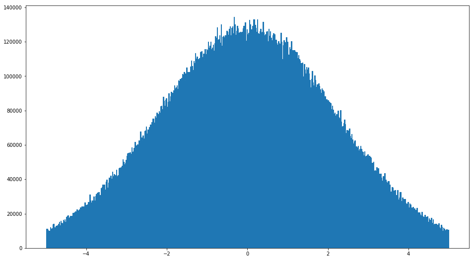

```python
plt.figure(figsize=fs)
plt.hist( [ x for x in hmc_Eta.edges[:-1] ],  weights=hmc_Eta.values, bins=hmc_Eta.edges, fill=True, histtype="step" );
```

[output not shown]

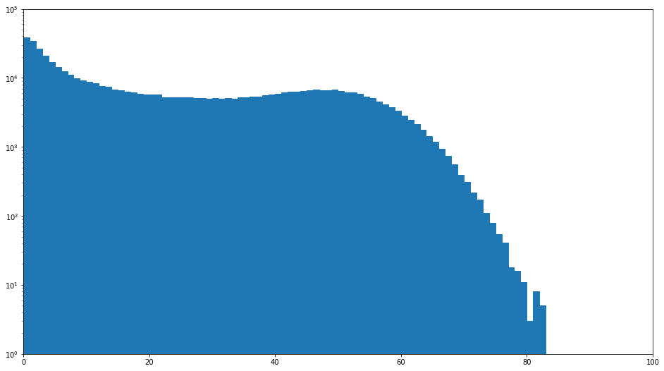

```python
plt.figure(figsize=fs)
hrc_Mult = fHist[b'hrc_Mult']
plt.hist( [ x for x in hrc_Mult.edges[:-1] ],  weights=hrc_Mult.values, bins=hrc_Mult.edges, fill=True, histtype="step" );
gca = plt.gca()
gca.set_yscale('log')
gca.set_ylim((1, 1e5))
gca.set_xlim((0, 100))
```

As you can see, the same basic procedure can be used to plot any TH1 type histogram, se we can define a helper function to do this. You can use something like this and add your own options for common settings:

```python
def plotTH1( h, **kwargs ) :

    # Make a figure, use the default size if the opt 'fs' is not given
    fs = kwargs.get( "fs", (16, 9) )
    plt.figure(figsize=fs)

    x = [ x for x in h.edges[:-1] ]
    plt.hist( x, weights=h.values, bins=h.edges, fill=True, histtype="step" );
    gca = plt.gca()

    # Activate logy by adding a keyword argument logy=True
    if kwargs.get( 'logy', False ) : gca.set_yscale('log')

    # Set the axis limits if given as keyword opts
    if 'ylim' in kwargs : gca.set_ylim( kwargs.get( 'ylim' ) )
    if 'xlim' in kwargs : gca.set_xlim( kwargs.get( 'xlim' ) )

    plt.show()
```

Usage examples:

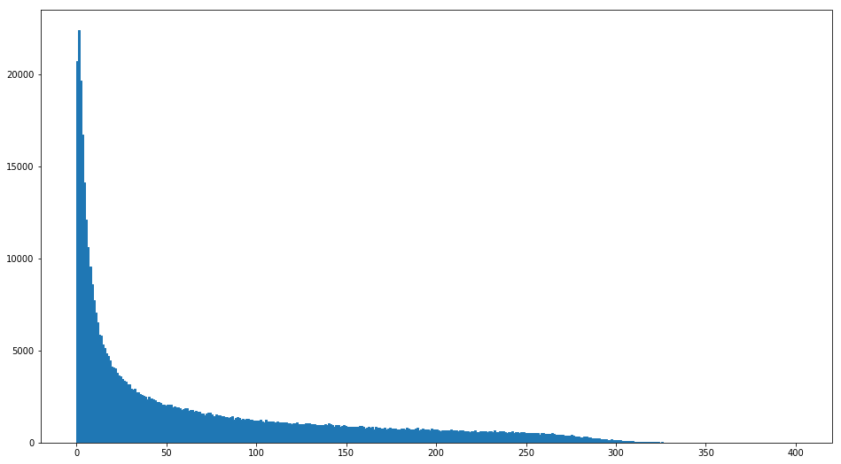

```python
# Default usage
plotTH1( fHist[b'hmc_Mult'] )
```

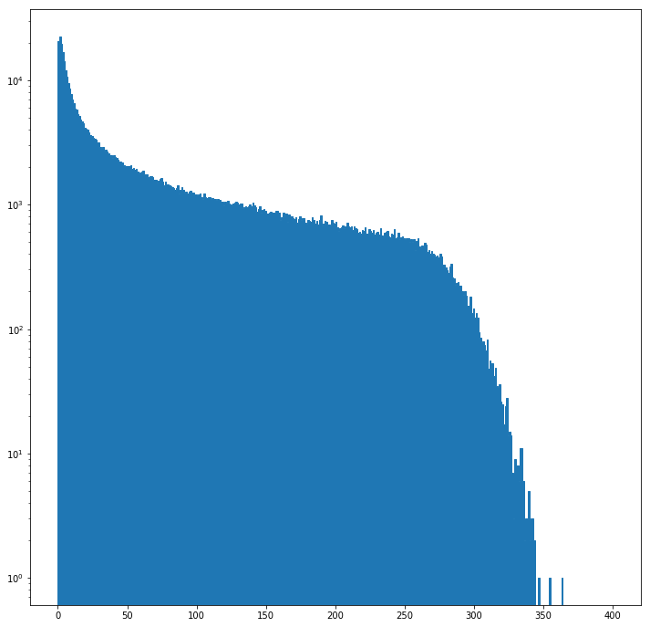

```python
# use a log y axis, and a different (square) figure size
plotTH1( fHist[b'hmc_Mult'], logy=True, fs=(12,12) )
```

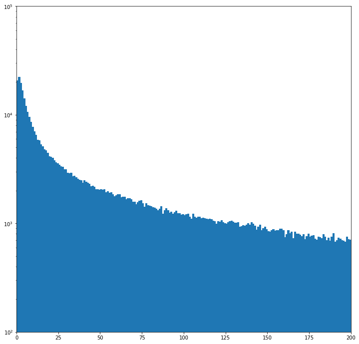

```python
# use a log y axis, and a different (square) figure size
# Set the xlimits and ylimits explicitly
plotTH1( fHist[b'hmc_Mult'], logy=True, fs=(12,12), ylim=(1e2, 1e5), xlim=(0, 200) )
```

### Plotting 2D histograms (comming soon)